# Исследование объявлений о продаже квартир

В вашем распоряжении данные сервиса Яндекc Недвижимость — архив объявлений о продаже квартир в Санкт-Петербурге и соседних населённых пунктах за несколько лет. Нужно научиться определять рыночную стоимость объектов недвижимости. Ваша задача — установить параметры. Это позволит построить автоматизированную систему: она отследит аномалии и мошенническую деятельность.

По каждой квартире на продажу доступны два вида данных. Первые вписаны пользователем, вторые получены автоматически на основе картографических данных. Например, расстояние до центра, аэропорта, ближайшего парка и водоёма.

## Изучение данных из файла

```python
import pandas as pd
import matplotlib.pyplot as plt
```

```python
#импортируем данные и поменяем тип данных в столбце first_day_exposition на "datetime"
df = pd.read_csv('/datasets/real_estate_data.csv', sep='\t', parse_dates=['first_day_exposition'])
display(df.head())
df.info()
#посмотрим есть ли дубликаты
df.duplicated().sum()
```

|  | total_images | last_price | total_area | first_day_exposition | rooms | ceiling_height | floors_total | living_area | floor | is_apartment | ... | kitchen_area | balcony | locality_name | airports_nearest | cityCenters_nearest | parks_around3000 | parks_nearest | ponds_around3000 | ponds_nearest | days_exposition |
| --- | --- | --- | --- | --- | --- | --- | --- | --- | --- | --- | --- | --- | --- | --- | --- | --- | --- | --- | --- | --- | --- |
| 0 | 20 | 13000000.0 | 108.0 | 2019-03-07 | 3 | 2.70 | 16.0 | 51.0 | 8 | NaN | ... | 25.0 | NaN | Санкт-Петербург | 18863.0 | 16028.0 | 1.0 | 482.0 | 2.0 | 755.0 | NaN |
| 1 | 7 | 3350000.0 | 40.4 | 2018-12-04 | 1 | NaN | 11.0 | 18.6 | 1 | NaN | ... | 11.0 | 2.0 | посёлок Шушары | 12817.0 | 18603.0 | 0.0 | NaN | 0.0 | NaN | 81.0 |
| 2 | 10 | 5196000.0 | 56.0 | 2015-08-20 | 2 | NaN | 5.0 | 34.3 | 4 | NaN | ... | 8.3 | 0.0 | Санкт-Петербург | 21741.0 | 13933.0 | 1.0 | 90.0 | 2.0 | 574.0 | 558.0 |
| 3 | 0 | 64900000.0 | 159.0 | 2015-07-24 | 3 | NaN | 14.0 | NaN | 9 | NaN | ... | NaN | 0.0 | Санкт-Петербург | 28098.0 | 6800.0 | 2.0 | 84.0 | 3.0 | 234.0 | 424.0 |
| 4 | 2 | 10000000.0 | 100.0 | 2018-06-19 | 2 | 3.03 | 14.0 | 32.0 | 13 | NaN | ... | 41.0 | NaN | Санкт-Петербург | 31856.0 | 8098.0 | 2.0 | 112.0 | 1.0 | 48.0 | 121.0 |

5 rows × 22 columns

```
<class 'pandas.core.frame.DataFrame'>
RangeIndex: 23699 entries, 0 to 23698
Data columns (total 22 columns):
 #   Column                Non-Null Count  Dtype
---  ------                --------------  -----
 0   total_images          23699 non-null  int64
 1   last_price            23699 non-null  float64
 2   total_area            23699 non-null  float64
 3   first_day_exposition  23699 non-null  datetime64[ns]
 4   rooms                 23699 non-null  int64
 5   ceiling_height        14504 non-null  float64
 6   floors_total          23613 non-null  float64
 7   living_area           21796 non-null  float64
 8   floor                 23699 non-null  int64
 9   is_apartment          2775 non-null   object
 10  studio                23699 non-null  bool
 11  open_plan             23699 non-null  bool
 12  kitchen_area          21421 non-null  float64
 13  balcony               12180 non-null  float64
 14  locality_name         23650 non-null  object
 15  airports_nearest      18157 non-null  float64
 16  cityCenters_nearest   18180 non-null  float64
 17  parks_around3000      18181 non-null  float64
 18  parks_nearest         8079 non-null   float64
 19  ponds_around3000      18181 non-null  float64
 20  ponds_nearest         9110 non-null   float64
 21  days_exposition       20518 non-null  float64
dtypes: bool(2), datetime64[ns](1), float64(14), int64(3), object(2)
memory usage: 3.7+ MB
```

```
0
```

```python
# %-ая доля пропущенных значений в столбцах
df.isna().mean()*100
```

```
total_images             0.000000
last_price               0.000000
total_area               0.000000
first_day_exposition     0.000000
rooms                    0.000000
ceiling_height          38.799105
floors_total             0.362885
living_area              8.029875
floor                    0.000000
is_apartment            88.290645
studio                   0.000000
open_plan                0.000000
kitchen_area             9.612220
balcony                 48.605426
locality_name            0.206760
airports_nearest        23.384953
cityCenters_nearest     23.287902
parks_around3000        23.283683
parks_nearest           65.909954
ponds_around3000        23.283683
ponds_nearest           61.559559
days_exposition         13.422507
dtype: float64
```

```python
pd.DataFrame(df.isna().mean().round(4)*100).sort_values(by=0)[::-1].style.background_gradient('coolwarm')
```

|  | 0 |
| --- | --- |
| is_apartment | 88.290000 |
| parks_nearest | 65.910000 |
| ponds_nearest | 61.560000 |
| balcony | 48.610000 |
| ceiling_height | 38.800000 |
| airports_nearest | 23.380000 |
| cityCenters_nearest | 23.290000 |
| parks_around3000 | 23.280000 |
| ponds_around3000 | 23.280000 |
| days_exposition | 13.420000 |
| kitchen_area | 9.610000 |
| living_area | 8.030000 |
| floors_total | 0.360000 |
| locality_name | 0.210000 |
| first_day_exposition | 0.000000 |
| last_price | 0.000000 |
| total_area | 0.000000 |
| studio | 0.000000 |
| rooms | 0.000000 |
| floor | 0.000000 |
| open_plan | 0.000000 |
| total_images | 0.000000 |

### Вывод

В датасете есть пропущенные значения, на следующем этапе обработаем их. Столбцу first_day_exposition изменили тип на "datetime". Столбцы: is_apartment, airports_nearest, parks_around3000, parks_nearest, ponds_around3000, ponds_nearest в проекте использоваться не будут, поэтому оставим в них данные как есть

## Предобработка данных

#### Столбец locality_name

Правдоподобно "вычислить" пропущенные названия возможности не предоставляется, при этом отсутствует всего 0.2% данных, поэтому удалим их:

```python
df.dropna(subset=['locality_name'], inplace=True)
df['locality_name'].isna().sum()
```

```
0
```

#### Столбец floors_total

0,4% данных нет, переведем число этажей в целочисленный тип и удалим пустые значения:

```python
df.dropna(subset=['floors_total'], inplace=True)
df['floors_total'] = df['floors_total'].astype(int)
df['floors_total'].isna().sum()
```

```
0
```

#### Столбец ceiling_height

Заменим пропущенные значения медианой высоты потолка:

```python
median = df['ceiling_height'].median()
df['ceiling_height'].fillna((median), inplace=True)
df['ceiling_height'].isna().sum()
```

```
0
```

```python
df['ceiling_height'].describe()
```

```
count    23565.000000
mean         2.724530
std          0.991026
min          1.000000
25%          2.600000
50%          2.650000
75%          2.700000
max        100.000000
Name: ceiling_height, dtype: float64
```

При массовой застройке минимальная высота потолков в квартире не может быть ниже 2,5м; сделаем допущение на неточность измерений, ремонт, натяжные потолки и т.д. - минимальная высота 2.2м, все что ниже - ошибка данных, отфильтруем их:

```python
df = df.loc[df['ceiling_height'] >= 2.2]
df['ceiling_height'].describe()
```

```
count    23551.000000
mean         2.725048
std          0.991063
min          2.200000
25%          2.600000
50%          2.650000
75%          2.700000
max        100.000000
Name: ceiling_height, dtype: float64
```

Посмотрим на аномалии высоты потолков "вверх":

```python
df['ceiling_height'].sort_values(ascending=False).head(20)
```

```
22869    100.0
3148      32.0
22336     32.0
21377     27.5
10773     27.0
5246      27.0
22938     27.0
21824     27.0
17857     27.0
4876      27.0
20478     27.0
5807      27.0
5669      26.0
6246      25.0
11285     25.0
4643      25.0
9379      25.0
14382     25.0
355       25.0
18545     25.0
Name: ceiling_height, dtype: float64
```

Высота потолков даже в "сталинках" не превышает 4м, поэтому все значения больше 4-х скорее всего ошибка данных; сделаем допущение, что в значениях 32.0 - 22.6 вероятно имелось ввиду 3.2 - 2.26, исправим это, а все что выше 4м отфильтруем:

```python
def height (value):
    if 22.6 <= value <= 32.0:
        return value / 10
    return value
df['ceiling_height'] = df['ceiling_height'].apply(height)
df = df.loc[df['ceiling_height'] <= 4]
df['ceiling_height'].describe()
```

```
count    23497.000000
mean         2.693638
std          0.204404
min          2.200000
25%          2.600000
50%          2.650000
75%          2.700000
max          4.000000
Name: ceiling_height, dtype: float64
```

#### Столбец kitchen_area

Заменим пропущенные значения для студий на нули:

```python
df.loc[df['studio'] == True, 'kitchen_area'] = 0
```

Вычислим средний коэффициент (kitchen_area/total_area) и через него заменим оставшиеся пустые значения в столбце:

```python
kitchen_k = df['kitchen_area'].mean() / df['total_area'].mean()
df['kitchen_area'].fillna(kitchen_k * df['total_area'], inplace=True)
#проверка
df['kitchen_area'].isna().sum()
```

```
0
```

#### Столбец living_area

Вычислим средний коэффициент (living_area/total_area) и через него заменим пустые значения в столбце:

```python
living_k = df['living_area'].mean() / df['total_area'].mean()
df['living_area'].fillna(living_k * df['total_area'], inplace=True)
#проверка
df['living_area'].isna().sum()
```

```
0
```

#### Столбец balcony

Если наличие балкона не указано, то скорее всего балкона просто нет, заменим пропущенные значения на 0, изменим тип на целочисленный:

```python
df['balcony'].fillna(0, inplace=True)
df['balcony'] = df['balcony'].astype(int)
df['balcony'].isna().value_counts()
```

```
False    23497
Name: balcony, dtype: int64
```

#### Столбец cityCenters_nearest

Для исследования нам нужны данные по городу Санкт-Петербург, посмотрим сколько там пропущенных значений:

```python
#посчитаем процент
((df['cityCenters_nearest'].isna()) & (df['locality_name']=='Санкт-Петербург')).sum()/len(df['locality_name']=='Санкт-Петербург')*100
```

```
0.25535174703153596
```

0.25% пропущенных значений, пока делать ничего не будем, оставим как есть

#### Столбец days_exposition

13,4% пропущенных значений, заполним их медианой и приведем к целочисленному типу:

```python
median_exp = df['days_exposition'].median()
df['days_exposition'].fillna((median_exp), inplace=True)
df['days_exposition'] = df['days_exposition'].astype(int)
df['days_exposition'].isna().value_counts()
```

```
False    23497
Name: days_exposition, dtype: int64
```

Посмотрим на обработанную таблицу:

```python
df.reset_index(drop=True, inplace=True)
df.info()
```

```
<class 'pandas.core.frame.DataFrame'>
RangeIndex: 23497 entries, 0 to 23496
Data columns (total 22 columns):
 #   Column                Non-Null Count  Dtype
---  ------                --------------  -----
 0   total_images          23497 non-null  int64
 1   last_price            23497 non-null  float64
 2   total_area            23497 non-null  float64
 3   first_day_exposition  23497 non-null  datetime64[ns]
 4   rooms                 23497 non-null  int64
 5   ceiling_height        23497 non-null  float64
 6   floors_total          23497 non-null  int64
 7   living_area           23497 non-null  float64
 8   floor                 23497 non-null  int64
 9   is_apartment          2749 non-null   object
 10  studio                23497 non-null  bool
 11  open_plan             23497 non-null  bool
 12  kitchen_area          23497 non-null  float64
 13  balcony               23497 non-null  int64
 14  locality_name         23497 non-null  object
 15  airports_nearest      17990 non-null  float64
 16  cityCenters_nearest   18010 non-null  float64
 17  parks_around3000      18011 non-null  float64
 18  parks_nearest         7995 non-null   float64
 19  ponds_around3000      18011 non-null  float64
 20  ponds_nearest         9000 non-null   float64
 21  days_exposition       23497 non-null  int64
dtypes: bool(2), datetime64[ns](1), float64(11), int64(6), object(2)
memory usage: 3.6+ MB
```

### Вывод

Обработали пропущенные значения; изменили тип данных, где это было уместно; отфильтровали некоторые аномалии

## Расчёты и добавление результатов в таблицу

#### Цена квадратного метра sq_price

```python
df['sq_price'] =df['last_price'] / df['total_area']
```

#### День недели, месяц и год публикации объявления

```python
df['weekday'] = df['first_day_exposition'].dt.weekday
df['month'] = df['first_day_exposition'].dt.month
df['year'] = df['first_day_exposition'].dt.year
```

#### Этаж квартиры floor_category (первый, последний, другой)

```python
df.loc[df['floor'] !=0, 'floor_category'] = 'другой'
df.loc[df['floor'] == df['floors_total'], 'floor_category'] = 'последний'
df.loc[df['floor'] == 1, 'floor_category'] = 'первый'
```

#### Соотношение жилой и общей площади living_ratio, а также отношение площади кухни к общей kitchen_ratio

```python
df['living_ratio'] = df['living_area'] / df['total_area']
df['kitchen_ratio'] = df['kitchen_area'] / df['total_area']
```

## Исследовательский анализ данных

### Изучение площади, цены, числа комнат, высоты потолков

#### Площадь

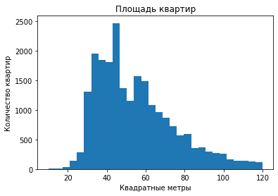

```python
plt.hist(df['total_area'], bins=30, range=(10,120))
plt.title('Площадь квартир')
plt.xlabel('Квадратные метры')
plt.ylabel('Количество квартир')
plt.show()
```

#### Цена

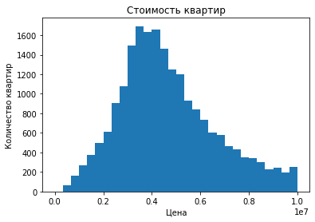

```python
plt.hist(df['last_price'], bins=30, range=(0,10000000))
plt.title('Стоимость квартир')
plt.xlabel('Цена')
plt.ylabel('Количество квартир')
plt.show()
```

#### Число комнат

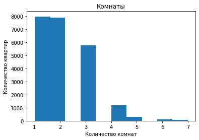

```python
plt.hist(df['rooms'], bins=10, range=(1,7))
plt.title('Комнаты')
plt.xlabel('Количество комнат')
plt.ylabel('Количество квартир')
plt.show()
```

#### Высота потолков

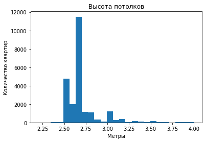

```python
plt.hist(df['ceiling_height'], bins=25)
plt.title('Высота потолков')
plt.xlabel('Метры')
plt.ylabel('Количество квартир')
plt.show()
```

### Изучение времени продажи квартиры

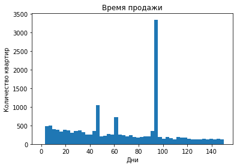

```python
plt.hist(df['days_exposition'], bins=50, range=(0,150))
plt.title('Время продажи')
plt.xlabel('Дни')
plt.ylabel('Количество квартир')
plt.show()
```

```python
df['days_exposition'].value_counts().head(15)
df['days_exposition'].describe().round()
```

```
count    23497.0
mean       169.0
std        206.0
min          1.0
25%         45.0
50%         95.0
75%        198.0
max       1580.0
Name: days_exposition, dtype: float64
```

### Вывод

Медианное время продажи квартиры - 95 дней, среднее время продажи - 169 дней. Обычно продажа занимает 95, 60 или 45 дней. Быстрая продажа - до 45 дней, долгая продажа - больше 198 дней

### Изучение редких и выбивающихся значений

Найдем и отфильтруем редкие и выбивающиеся значения через межквартильный размах и "усы", равные 1.5 межквартильным размахам (IQR). В размах 'усов" попадают нормальные значения, а за пределами находятся выбросы:

```python
def iqr_range (data, column):
    q1 = df[column].describe()[4]
    q3 = df[column].describe()[6]
    iqr = q3-q1
    df_iqr = data.loc[(data[column] < q3 + 1.5*iqr) & (data[column] > q1 - 1.5*iqr), column]
    return df_iqr
#список анализируемых столбцов
a_list = ['total_area', 'last_price', 'rooms', 'ceiling_height', 'days_exposition']
for i in a_list:
    df[i] = iqr_range(df, i)
df[['total_area', 'last_price', 'rooms', 'ceiling_height', 'days_exposition']].describe()
```

|  | total_area | last_price | rooms | ceiling_height | days_exposition |
| --- | --- | --- | --- | --- | --- |
| count | 22247.000000 | 2.145500e+04 | 23308.000000 | 20618.000000 | 21173.000000 |
| mean | 54.223076 | 4.828485e+06 | 2.029089 | 2.631075 | 112.749870 |
| std | 19.202672 | 2.203210e+06 | 0.972313 | 0.081491 | 96.318341 |
| min | 12.000000 | 1.219000e+04 | 0.000000 | 2.460000 | 1.000000 |
| 25% | 39.400000 | 3.300000e+06 | 1.000000 | 2.600000 | 45.000000 |
| 50% | 50.000000 | 4.400000e+06 | 2.000000 | 2.650000 | 95.000000 |
| 75% | 65.300000 | 5.990000e+06 | 3.000000 | 2.650000 | 146.000000 |
| max | 113.600000 | 1.176800e+07 | 5.000000 | 2.850000 | 427.000000 |

```python
# КОД РЕВЬЮЕРА

df[['last_price', 'total_area','rooms', 'ceiling_height', 'days_exposition']].describe().loc[['min', 'max']]
```

|  | last_price | total_area | rooms | ceiling_height | days_exposition |
| --- | --- | --- | --- | --- | --- |
| min | 12190.0 | 12.0 | 0.0 | 2.46 | 1.0 |
| max | 11768000.0 | 113.6 | 5.0 | 2.85 | 427.0 |

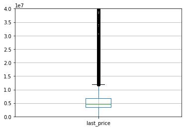

```python
# КОД РЕВЬЮЕРА 2

df2 = pd.read_csv('/datasets/real_estate_data.csv', sep='\t', parse_dates=['first_day_exposition'])
df2.boxplot(column = 'last_price')
plt.ylim(0,40e6);
```

### Вывод

"Хвосты" отброшены, данные стали чише

### Определение факторов, влияющих на стоимость квартиры

#### Цена и площадь

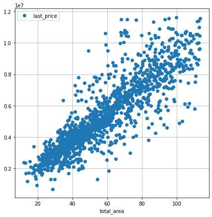

```python
(
    df.pivot_table(index='total_area', values='last_price')
    .plot(grid=True, style='o', figsize=(7, 7))
)
plt.show()
```

Почти прямая и логичная зависимость, чем больше плошадь, тем дороже квартира

#### Цена и колличество комнат

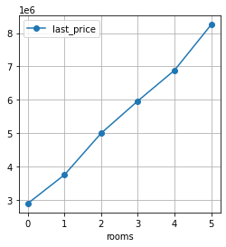

```python
(
    df.pivot_table(index='rooms', values='last_price')
    .plot(grid=True, style='-o', figsize=(4, 4))
)
plt.show()
```

#### Цена и удалённость от центра

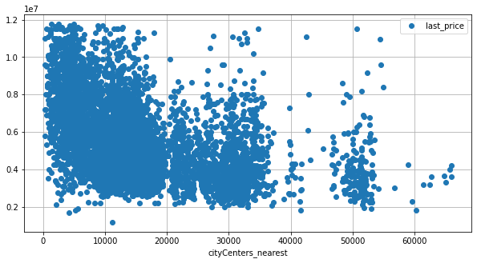

```python
(
    df.pivot_table(index='cityCenters_nearest', values='last_price')
    .plot(grid=True, style='o', figsize=(10, 5))
)
plt.show()
```

Большинство дорогих квартир расположены в центре или около, но там же есть и часть дешевых. В целом - чем дальше от центра, тем ниже цена, но при этом есть и несколько очень дорогих квартир расположенных далеко от центра

#### Цена и этаж

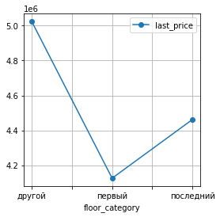

```python
(
    df.pivot_table(index='floor_category', values='last_price')
    .plot(grid=True, style='-o', figsize=(4, 4))
)
plt.show()
```

#### Цена и дата (неделя, месяц, год)

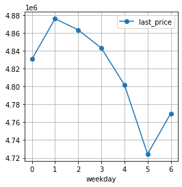

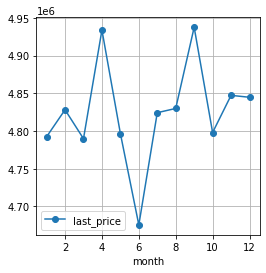

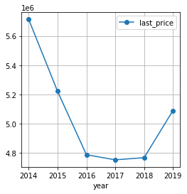

```python
(
    df.pivot_table(index='weekday', values='last_price')
    .plot(grid=True, style='-o', figsize=(4, 4))
)
plt.show()
(
    df.pivot_table(index='month', values='last_price')
    .plot(grid=True, style='-o', figsize=(4, 4))
)
plt.show()
(
    df.pivot_table(index='year', values='last_price')
    .plot(grid=True, style='-o', figsize=(4, 4))
)
plt.show()
```

Самые лучшие дни для выставления на продажу - вторник и среда, худшие - суббота и воскресенье  
Апрель и сентябрь - лучшие месяцы для продажи, в июне - можно и не пытаться  
2014 - самый дорогой год, затем 2 года спада и стагнация до 2019, где начался небольшой рост

### Вывод

Чем больше квартира, тем дороже она стоит; "первый и последний этажи не предлагать" - это подтверждается деньгами; ближе к центру - дороже квартира, в целом "да", но не всегда; продавать лучше в начале недели в апреле и сентябре, а покупать в выходные в июне; тот кто не продал в 2014 - опоздал, "окончательно и бесповоротно"

### Топ-10 городов по числу объявлений и анализ стоимости в них квадратного метра

```python
top_10 = df.groupby('locality_name')['sq_price'].agg(['count', 'mean']).sort_values(by='count', ascending=False).head(10)
top_10.columns = ['count_flats', 'sq_price']
top_10['sq_price'] = top_10['sq_price'].astype(int)
top_10
```

| locality_name | count_flats | sq_price |
| --- | --- | --- |
| Санкт-Петербург | 15600 | 114635 |
| посёлок Мурино | 520 | 85673 |
| посёлок Шушары | 439 | 78551 |
| Всеволожск | 396 | 68670 |
| Пушкин | 368 | 103058 |
| Колпино | 338 | 75424 |
| посёлок Парголово | 327 | 90175 |
| Гатчина | 307 | 68746 |
| деревня Кудрово | 299 | 92473 |
| Выборг | 234 | 58190 |

### Вывод

Самый дорогой квадратный метр в Питере, ему совсем немного уступает Пушкин. Самые дешевые метры в Выборге

### Определение центральной зоны в Санкт-Петербурге

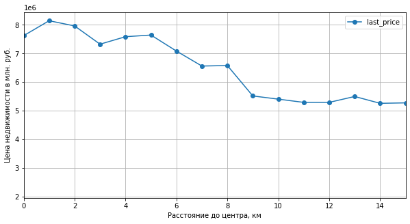

```python
#фильтр на Санкт-Петербург
spb = df.loc[df['locality_name']=='Санкт-Петербург',['last_price', 'cityCenters_nearest']]
#добавляем столбец с расстоянием до центра в км
spb['center_km'] = round(spb['cityCenters_nearest']/1000)
#строим график
(
    spb.pivot_table(index='center_km', values='last_price')
    .plot(grid=True, style='-o', xlim=(0,15), figsize=(10, 5))
)

plt.ylabel('Цена недвижимости в млн. руб.')
plt.xlabel('Расстояние до центра, км')
plt.show()
```

### Вывод

Центральная зона Санкт-Петербурга, через стоимость недвижимости, определяется довольно четко - радиус 8км от центра

### Анализ квартир в центральном сегменте Санкт-Петербурга

#### Площадь, цена, число комнат, высота потолков

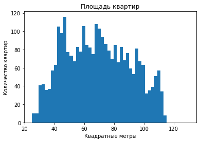

```python
#выделяем сегмент квартир в центре Питера
spb_center = df.query('(locality_name == "Санкт-Петербург") & (cityCenters_nearest <= 8000)')
#плошадь
plt.hist(spb_center['total_area'], bins=50, range=(25,130))
plt.title('Площадь квартир')
plt.xlabel('Квадратные метры')
plt.ylabel('Количество квартир')
plt.show()
```

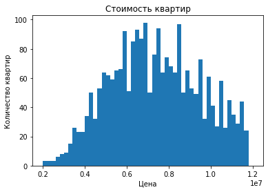

```python
#цена
plt.hist(spb_center['last_price'], bins=50, range=(2000000,12000000))
plt.title('Стоимость квартир')
plt.xlabel('Цена')
plt.ylabel('Количество квартир')
plt.show()
```

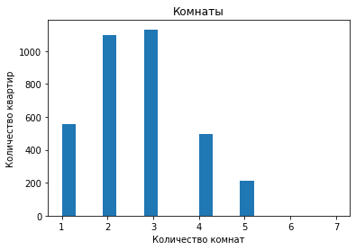

```python
#число комнат
plt.hist(spb_center['rooms'], bins=20, range=(1,7))
plt.title('Комнаты')
plt.xlabel('Количество комнат')
plt.ylabel('Количество квартир')
plt.show()
```

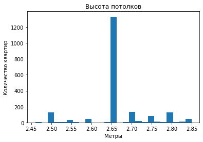

```python
#высота потолков
plt.hist(spb_center['ceiling_height'], bins=25)
plt.title('Высота потолков')
plt.xlabel('Метры')
plt.ylabel('Количество квартир')
plt.show()
```

```python
round(spb_center['rooms']).value_counts().head(15)
```

```
3.0    1132
2.0    1097
1.0     555
4.0     499
5.0     210
0.0      17
Name: rooms, dtype: int64
```

**Площадь** - наибольшее число квартир имеет плошадь 42-45 и 70-75 кв.м, также в центре большое число квартир больше 100 кв.м  
**Цена** - большая часть квартир стоит в диапазоне 6.2-6.8 и 8.0-8.5 миллионов руб., дорогих квартир (>10 млн.) в центре больше чем дешевых (<4 млн.)  
**Число комнат** - 3-х комнатных больше всего, у 2-х комнатных второе, а 4-х комнатных почти столько же сколько однокомнатных  
**Высота потолков** - Самые распротранненый вариант 2.65 метра

#### Анализ влияния числа комнат, этажа, удалённости от центра, даты размещения объявления на стоимость квартиры в центре

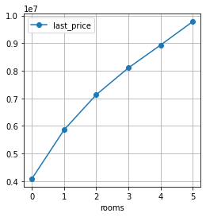

```python
#число комнат
(
    spb_center.pivot_table(index='rooms', values='last_price')
    .plot(grid=True, style='-o', figsize=(4, 4))
)
plt.show()
```

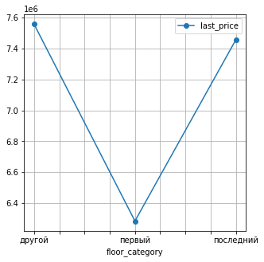

```python
#этаж
(
    spb_center.pivot_table(index='floor_category', values='last_price')
    .plot(grid=True, style='-o', figsize=(5, 5))
)
plt.show()
```

Первый этаж не предлагать, особенно в центре, зато остальные рассмотрят, даже последние

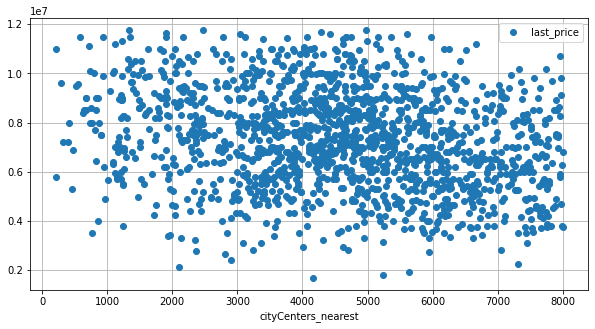

```python
#удаленность от центра
(
    spb_center.pivot_table(index='cityCenters_nearest', values='last_price')
    .plot(grid=True, style='o', figsize=(10, 5))
)
plt.show()
```

В центральной зоне уже не важно, как именно близко вы живете к центру, дорогие и дешевые квартиры есть везде; близость к центру на цену уже не влияет

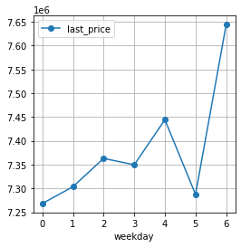

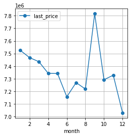

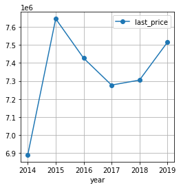

```python
#неделя, месяц, год
(
    spb_center.pivot_table(index='weekday', values='last_price')
    .plot(grid=True, style='-o', figsize=(4, 4))
)
plt.show()
(
    spb_center.pivot_table(index='month', values='last_price')
    .plot(grid=True, style='-o', figsize=(4, 4))
)
plt.show()
(
    spb_center.pivot_table(index='year', values='last_price')
    .plot(grid=True, style='-o', figsize=(4, 4))
)
plt.show()
```

Абсолютно лучший день для продажи - воскресенье, а худшие - понедельник, вторник и суббота.  
В декабре ничего не продается, а в сентябре разбирают все  
2014 - худший год по цене, а 2015 - лучший, потом спад и с 2018 - подьем

### Вывод

Плошадь и стоимость квартир в центре Питера, заметно больше, чем по всей базе. В центре покупают 3-ки, 2-ки или даже 4-х комнатные квартиры, тогда как большинство может себе позволить 1-ку или в лучшем случае 2-ку. Высота потолков чаще всего 2,65, везде. Первые этажи никто не любит, последние - нормально только для центра, иначе продавать придется с дисконтом. В субботу лучше объявление не выставлять; cентябрь лучший месяц для продажи везде, а вот в июне лучше не пытаться. 2014-2015 начало кризиса, дальше падение и начало роста в 2018-2019 годах